# Манипуляции с данными с помощью пакета dplyr: решение заданий

Зарманбетов Ахмед

Установим и подгрузим пакеты.

```r
# install.packages('readr')
# install.packages('dplyr')
# install.packages('ggplot2')
library(readr)
library(dplyr)
library(ggplot2)
```

### Задание №1

Будем работать с файликом *counties.rds*. Формат *.rds* это формат данных для R, который сохраняет ваш *df* в том виде, в котором вы его видели. Его очень легко подгрузить с помощью функции `read_rds()`.

```r
counties <- read_rds('data/counties.rds')
```

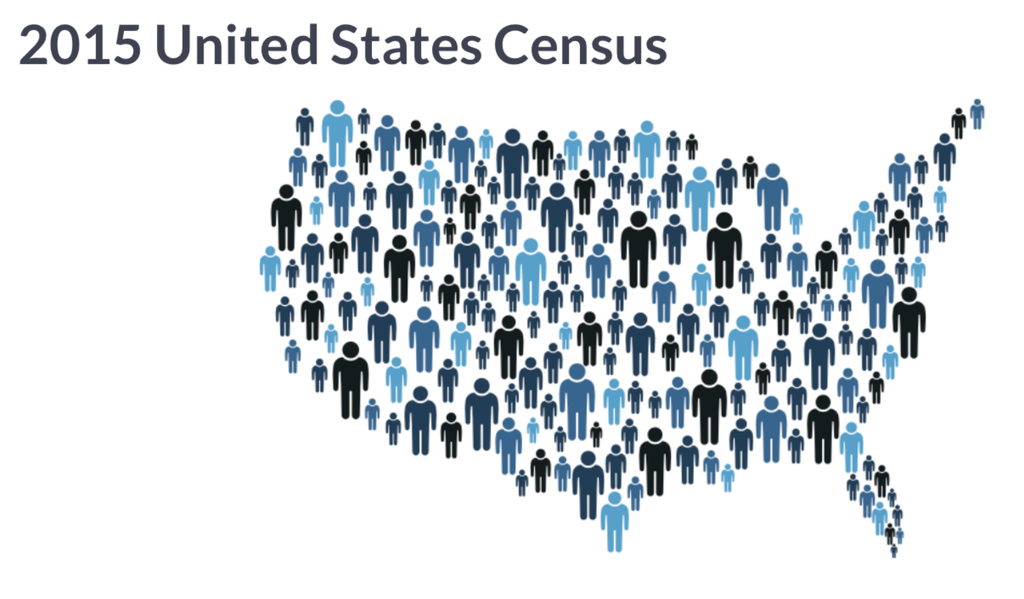

Этот набор данных, сформированный после переписи населения США в 2015 году.

Немножко информации о некоторых переменных:

- `state` – название штата США (всего 50)
- `county` – округ штата
- `region` – регион
- `metro` – есть ли метро
- `population` – количество жителей
- `men` – количество мужчин
- `women` – количество женщин
- `unemployment` – процент безработицы
- `land area` – площадь округа
- `private_work`, `public_work`, `self_employed`, `family_work` – процент работающих на частные компании, на государство, на себя и процент работающих в семейном бизнесе
- `employed` – частный предприниматель
- `income` – доход
- `walk` – количество граждан (в %), которые ходят на работу пешком
- Сколько наблюдений и переменных в нашем наборе данных? Что является наблюдением? Какое первое значение в переменной `income`?

```r
glimpse(counties)
```

```
## Observations: 3,138
## Variables: 40
## $ census_id          <chr> "1001", "1003", "1005", "1007", "1009", "1011…
## $ state              <chr> "Alabama", "Alabama", "Alabama", "Alabama", "…
## $ county             <chr> "Autauga", "Baldwin", "Barbour", "Bibb", "Blo…
## $ region             <chr> "South", "South", "South", "South", "South", …
## $ metro              <chr> "Metro", "Metro", "Nonmetro", "Metro", "Metro…
## $ population         <dbl> 55221, 195121, 26932, 22604, 57710, 10678, 20…
## $ men                <dbl> 26745, 95314, 14497, 12073, 28512, 5660, 9502…
## $ women              <dbl> 28476, 99807, 12435, 10531, 29198, 5018, 1085…
## $ hispanic           <dbl> 2.6, 4.5, 4.6, 2.2, 8.6, 4.4, 1.2, 3.5, 0.4, …
## $ white              <dbl> 75.8, 83.1, 46.2, 74.5, 87.9, 22.2, 53.3, 73.…
## $ black              <dbl> 18.5, 9.5, 46.7, 21.4, 1.5, 70.7, 43.8, 20.3,…
## $ native             <dbl> 0.4, 0.6, 0.2, 0.4, 0.3, 1.2, 0.1, 0.2, 0.2, …
## $ asian              <dbl> 1.0, 0.7, 0.4, 0.1, 0.1, 0.2, 0.4, 0.9, 0.8, …
```

[output cut: 27 more lines]

- Отберите наблюдения только для штатов `California`.

```r
counties %>%
  filter(state == 'California')
```

```
## # A tibble: 58 x 40
##    census_id state county region metro population    men  women hispanic
##    <chr>     <chr> <chr>  <chr>  <chr>      <dbl>  <dbl>  <dbl>    <dbl>
##  1 6001      Cali… Alame… West   Metro    1584983 776699 808284     22.6
##  2 6003      Cali… Alpine West   Nonm…       1131    654    477      9.5
##  3 6005      Cali… Amador West   Nonm…      36995  20012  16983     12.9
##  4 6007      Cali… Butte  West   Metro     222564 110115 112449     15.2
##  5 6009      Cali… Calav… West   Nonm…      44767  22143  22624     11.1
##  6 6011      Cali… Colusa West   Nonm…      21396  11129  10267     57.4
##  7 6013      Cali… Contr… West   Metro    1096068 534618 561450     24.9
##  8 6015      Cali… Del N… West   Nonm…      27788  15418  12370     19.1
##  9 6017      Cali… El Do… West   Metro     182093  90970  91123     12.5
## 10 6019      Cali… Fresno West   Metro     956749 477316 479433     51.6
## # … with 48 more rows, and 31 more variables: white <dbl>, black <dbl>,
## #   native <dbl>, asian <dbl>, pacific <dbl>, citizens <dbl>,
## #   income <dbl>, income_err <dbl>, income_per_cap <dbl>,
## #   income_per_cap_err <dbl>, poverty <dbl>, child_poverty <dbl>,
## #   professional <dbl>, service <dbl>, office <dbl>, construction <dbl>,
## #   production <dbl>, drive <dbl>, carpool <dbl>, transit <dbl>,
## #   walk <dbl>, other_transp <dbl>, work_at_home <dbl>,
## #   mean_commute <dbl>, employed <dbl>, private_work <dbl>,
## #   public_work <dbl>, self_employed <dbl>, family_work <dbl>,
## #   unemployment <dbl>, land_area <dbl>
```

- Отберите наблюдения только для штатов `California` и `Florida`.

```r
counties %>%
  filter(state == 'California' | state == 'Florida')
```

```
## # A tibble: 125 x 40
##    census_id state county region metro population    men  women hispanic
##    <chr>     <chr> <chr>  <chr>  <chr>      <dbl>  <dbl>  <dbl>    <dbl>
##  1 6001      Cali… Alame… West   Metro    1584983 776699 808284     22.6
##  2 6003      Cali… Alpine West   Nonm…       1131    654    477      9.5
##  3 6005      Cali… Amador West   Nonm…      36995  20012  16983     12.9
##  4 6007      Cali… Butte  West   Metro     222564 110115 112449     15.2
##  5 6009      Cali… Calav… West   Nonm…      44767  22143  22624     11.1
##  6 6011      Cali… Colusa West   Nonm…      21396  11129  10267     57.4
##  7 6013      Cali… Contr… West   Metro    1096068 534618 561450     24.9
##  8 6015      Cali… Del N… West   Nonm…      27788  15418  12370     19.1
##  9 6017      Cali… El Do… West   Metro     182093  90970  91123     12.5
## 10 6019      Cali… Fresno West   Metro     956749 477316 479433     51.6
## # … with 115 more rows, and 31 more variables: white <dbl>, black <dbl>,
## #   native <dbl>, asian <dbl>, pacific <dbl>, citizens <dbl>,
## #   income <dbl>, income_err <dbl>, income_per_cap <dbl>,
## #   income_per_cap_err <dbl>, poverty <dbl>, child_poverty <dbl>,
## #   professional <dbl>, service <dbl>, office <dbl>, construction <dbl>,
## #   production <dbl>, drive <dbl>, carpool <dbl>, transit <dbl>,
## #   walk <dbl>, other_transp <dbl>, work_at_home <dbl>,
## #   mean_commute <dbl>, employed <dbl>, private_work <dbl>,
## #   public_work <dbl>, self_employed <dbl>, family_work <dbl>,
## #   unemployment <dbl>, land_area <dbl>
```

- Отберите наблюдения только для штатов `California`, `Florida`, `Alabama` и `Indiana`.

```r
counties %>%
  filter(state %in% c('California', 'Florida', 'Alabama', 'Indiana'))
```

```
## # A tibble: 284 x 40
##    census_id state county region metro population   men women hispanic
##    <chr>     <chr> <chr>  <chr>  <chr>      <dbl> <dbl> <dbl>    <dbl>
##  1 1001      Alab… Autau… South  Metro      55221 26745 28476      2.6
##  2 1003      Alab… Baldw… South  Metro     195121 95314 99807      4.5
##  3 1005      Alab… Barbo… South  Nonm…      26932 14497 12435      4.6
##  4 1007      Alab… Bibb   South  Metro      22604 12073 10531      2.2
##  5 1009      Alab… Blount South  Metro      57710 28512 29198      8.6
##  6 1011      Alab… Bullo… South  Nonm…      10678  5660  5018      4.4
##  7 1013      Alab… Butler South  Nonm…      20354  9502 10852      1.2
##  8 1015      Alab… Calho… South  Metro     116648 56274 60374      3.5
##  9 1017      Alab… Chamb… South  Nonm…      34079 16258 17821      0.4
## 10 1019      Alab… Chero… South  Nonm…      26008 12975 13033      1.5
## # … with 274 more rows, and 31 more variables: white <dbl>, black <dbl>,
## #   native <dbl>, asian <dbl>, pacific <dbl>, citizens <dbl>,
## #   income <dbl>, income_err <dbl>, income_per_cap <dbl>,
## #   income_per_cap_err <dbl>, poverty <dbl>, child_poverty <dbl>,
## #   professional <dbl>, service <dbl>, office <dbl>, construction <dbl>,
## #   production <dbl>, drive <dbl>, carpool <dbl>, transit <dbl>,
## #   walk <dbl>, other_transp <dbl>, work_at_home <dbl>,
## #   mean_commute <dbl>, employed <dbl>, private_work <dbl>,
## #   public_work <dbl>, self_employed <dbl>, family_work <dbl>,
## #   unemployment <dbl>, land_area <dbl>
```

- Отберите округа с количеством населения не меньше 20000 только для штатов `California`, `Florida`, `Alabama` и `Indiana`.

```r
counties %>%
  filter(state %in% c('California', 'Florida', 'Alabama', 'Indiana'), population >= 20000)
```

```
## # A tibble: 226 x 40
##    census_id state county region metro population   men women hispanic
##    <chr>     <chr> <chr>  <chr>  <chr>      <dbl> <dbl> <dbl>    <dbl>
##  1 1001      Alab… Autau… South  Metro      55221 26745 28476      2.6
##  2 1003      Alab… Baldw… South  Metro     195121 95314 99807      4.5
##  3 1005      Alab… Barbo… South  Nonm…      26932 14497 12435      4.6
##  4 1007      Alab… Bibb   South  Metro      22604 12073 10531      2.2
##  5 1009      Alab… Blount South  Metro      57710 28512 29198      8.6
##  6 1013      Alab… Butler South  Nonm…      20354  9502 10852      1.2
##  7 1015      Alab… Calho… South  Metro     116648 56274 60374      3.5
##  8 1017      Alab… Chamb… South  Nonm…      34079 16258 17821      0.4
##  9 1019      Alab… Chero… South  Nonm…      26008 12975 13033      1.5
## 10 1021      Alab… Chilt… South  Metro      43819 21619 22200      7.6
## # … with 216 more rows, and 31 more variables: white <dbl>, black <dbl>,
## #   native <dbl>, asian <dbl>, pacific <dbl>, citizens <dbl>,
## #   income <dbl>, income_err <dbl>, income_per_cap <dbl>,
## #   income_per_cap_err <dbl>, poverty <dbl>, child_poverty <dbl>,
## #   professional <dbl>, service <dbl>, office <dbl>, construction <dbl>,
## #   production <dbl>, drive <dbl>, carpool <dbl>, transit <dbl>,
## #   walk <dbl>, other_transp <dbl>, work_at_home <dbl>,
## #   mean_commute <dbl>, employed <dbl>, private_work <dbl>,
## #   public_work <dbl>, self_employed <dbl>, family_work <dbl>,
## #   unemployment <dbl>, land_area <dbl>
```

- Отберите все округа кроме округов штата `California`.

```r
counties %>%
  filter(state != 'California')
```

```
## # A tibble: 3,080 x 40
##    census_id state county region metro population   men women hispanic
##    <chr>     <chr> <chr>  <chr>  <chr>      <dbl> <dbl> <dbl>    <dbl>
##  1 1001      Alab… Autau… South  Metro      55221 26745 28476      2.6
##  2 1003      Alab… Baldw… South  Metro     195121 95314 99807      4.5
##  3 1005      Alab… Barbo… South  Nonm…      26932 14497 12435      4.6
##  4 1007      Alab… Bibb   South  Metro      22604 12073 10531      2.2
##  5 1009      Alab… Blount South  Metro      57710 28512 29198      8.6
##  6 1011      Alab… Bullo… South  Nonm…      10678  5660  5018      4.4
##  7 1013      Alab… Butler South  Nonm…      20354  9502 10852      1.2
##  8 1015      Alab… Calho… South  Metro     116648 56274 60374      3.5
##  9 1017      Alab… Chamb… South  Nonm…      34079 16258 17821      0.4
## 10 1019      Alab… Chero… South  Nonm…      26008 12975 13033      1.5
## # … with 3,070 more rows, and 31 more variables: white <dbl>, black <dbl>,
## #   native <dbl>, asian <dbl>, pacific <dbl>, citizens <dbl>,
## #   income <dbl>, income_err <dbl>, income_per_cap <dbl>,
## #   income_per_cap_err <dbl>, poverty <dbl>, child_poverty <dbl>,
## #   professional <dbl>, service <dbl>, office <dbl>, construction <dbl>,
## #   production <dbl>, drive <dbl>, carpool <dbl>, transit <dbl>,
## #   walk <dbl>, other_transp <dbl>, work_at_home <dbl>,
## #   mean_commute <dbl>, employed <dbl>, private_work <dbl>,
## #   public_work <dbl>, self_employed <dbl>, family_work <dbl>,
## #   unemployment <dbl>, land_area <dbl>
```

- Отсортируйте в алфавитном порядке названия штатов.

```r
counties %>%
  arrange(state)
```

```
## # A tibble: 3,138 x 40
##    census_id state county region metro population   men women hispanic
##    <chr>     <chr> <chr>  <chr>  <chr>      <dbl> <dbl> <dbl>    <dbl>
##  1 1001      Alab… Autau… South  Metro      55221 26745 28476      2.6
##  2 1003      Alab… Baldw… South  Metro     195121 95314 99807      4.5
##  3 1005      Alab… Barbo… South  Nonm…      26932 14497 12435      4.6
##  4 1007      Alab… Bibb   South  Metro      22604 12073 10531      2.2
##  5 1009      Alab… Blount South  Metro      57710 28512 29198      8.6
##  6 1011      Alab… Bullo… South  Nonm…      10678  5660  5018      4.4
##  7 1013      Alab… Butler South  Nonm…      20354  9502 10852      1.2
##  8 1015      Alab… Calho… South  Metro     116648 56274 60374      3.5
##  9 1017      Alab… Chamb… South  Nonm…      34079 16258 17821      0.4
## 10 1019      Alab… Chero… South  Nonm…      26008 12975 13033      1.5
## # … with 3,128 more rows, and 31 more variables: white <dbl>, black <dbl>,
## #   native <dbl>, asian <dbl>, pacific <dbl>, citizens <dbl>,
## #   income <dbl>, income_err <dbl>, income_per_cap <dbl>,
## #   income_per_cap_err <dbl>, poverty <dbl>, child_poverty <dbl>,
## #   professional <dbl>, service <dbl>, office <dbl>, construction <dbl>,
## #   production <dbl>, drive <dbl>, carpool <dbl>, transit <dbl>,
## #   walk <dbl>, other_transp <dbl>, work_at_home <dbl>,
## #   mean_commute <dbl>, employed <dbl>, private_work <dbl>,
## #   public_work <dbl>, self_employed <dbl>, family_work <dbl>,
## #   unemployment <dbl>, land_area <dbl>
```

- Отсортируйте в алфавитном порядке названия штатов и округов.

```r
counties %>%
  arrange(state, county)
```

```
## # A tibble: 3,138 x 40
##    census_id state county region metro population   men women hispanic
##    <chr>     <chr> <chr>  <chr>  <chr>      <dbl> <dbl> <dbl>    <dbl>
##  1 1001      Alab… Autau… South  Metro      55221 26745 28476      2.6
##  2 1003      Alab… Baldw… South  Metro     195121 95314 99807      4.5
##  3 1005      Alab… Barbo… South  Nonm…      26932 14497 12435      4.6
##  4 1007      Alab… Bibb   South  Metro      22604 12073 10531      2.2
##  5 1009      Alab… Blount South  Metro      57710 28512 29198      8.6
##  6 1011      Alab… Bullo… South  Nonm…      10678  5660  5018      4.4
##  7 1013      Alab… Butler South  Nonm…      20354  9502 10852      1.2
##  8 1015      Alab… Calho… South  Metro     116648 56274 60374      3.5
##  9 1017      Alab… Chamb… South  Nonm…      34079 16258 17821      0.4
## 10 1019      Alab… Chero… South  Nonm…      26008 12975 13033      1.5
## # … with 3,128 more rows, and 31 more variables: white <dbl>, black <dbl>,
## #   native <dbl>, asian <dbl>, pacific <dbl>, citizens <dbl>,
## #   income <dbl>, income_err <dbl>, income_per_cap <dbl>,
## #   income_per_cap_err <dbl>, poverty <dbl>, child_poverty <dbl>,
## #   professional <dbl>, service <dbl>, office <dbl>, construction <dbl>,
## #   production <dbl>, drive <dbl>, carpool <dbl>, transit <dbl>,
## #   walk <dbl>, other_transp <dbl>, work_at_home <dbl>,
## #   mean_commute <dbl>, employed <dbl>, private_work <dbl>,
## #   public_work <dbl>, self_employed <dbl>, family_work <dbl>,
## #   unemployment <dbl>, land_area <dbl>
```

- Отсортируйте округи в порядке убывания численности населения. Какой штат и округ имеют наибольшую численность населения?

```r
counties %>%
  arrange(desc(population))
```

```
## # A tibble: 3,138 x 40
##    census_id state county region metro population    men  women hispanic
##    <chr>     <chr> <chr>  <chr>  <chr>      <dbl>  <dbl>  <dbl>    <dbl>
##  1 6037      Cali… Los A… West   Metro   10038388 4.95e6 5.09e6     48.2
##  2 17031     Illi… Cook   North… Metro    5236393 2.54e6 2.70e6     24.7
##  3 48201     Texas Harris South  Metro    4356362 2.17e6 2.19e6     41.6
##  4 4013      Ariz… Maric… West   Metro    4018143 1.99e6 2.03e6     30.1
##  5 6073      Cali… San D… West   Metro    3223096 1.62e6 1.60e6     32.9
##  6 6059      Cali… Orange West   Metro    3116069 1.54e6 1.58e6     34.2
##  7 12086     Flor… Miami… South  Metro    2639042 1.28e6 1.36e6     65.6
##  8 36047     New … Kings  North… Metro    2595259 1.23e6 1.37e6     19.6
##  9 48113     Texas Dallas South  Metro    2485003 1.23e6 1.26e6     39
## 10 36081     New … Queens North… Metro    2301139 1.12e6 1.19e6     27.9
## # … with 3,128 more rows, and 31 more variables: white <dbl>, black <dbl>,
## #   native <dbl>, asian <dbl>, pacific <dbl>, citizens <dbl>,
## #   income <dbl>, income_err <dbl>, income_per_cap <dbl>,
## #   income_per_cap_err <dbl>, poverty <dbl>, child_poverty <dbl>,
## #   professional <dbl>, service <dbl>, office <dbl>, construction <dbl>,
## #   production <dbl>, drive <dbl>, carpool <dbl>, transit <dbl>,
## #   walk <dbl>, other_transp <dbl>, work_at_home <dbl>,
## #   mean_commute <dbl>, employed <dbl>, private_work <dbl>,
## #   public_work <dbl>, self_employed <dbl>, family_work <dbl>,
## #   unemployment <dbl>, land_area <dbl>
```

- Отберите переменные `state`, `county`, `population` и `unemployment`.

```r
counties %>%
  select(state, county, population, unemployment)
```

```
## # A tibble: 3,138 x 4
##    state   county   population unemployment
##    <chr>   <chr>         <dbl>        <dbl>
##  1 Alabama Autauga       55221          7.6
##  2 Alabama Baldwin      195121          7.5
##  3 Alabama Barbour       26932         17.6
##  4 Alabama Bibb          22604          8.3
##  5 Alabama Blount        57710          7.7
##  6 Alabama Bullock       10678         18
##  7 Alabama Butler        20354         10.9
##  8 Alabama Calhoun      116648         12.3
##  9 Alabama Chambers      34079          8.9
## 10 Alabama Cherokee      26008          7.9
## # … with 3,128 more rows
```

- Отберите переменные `state`, `county`, `region`, `metro`, `population`, `men` и `women`.

```r
counties %>%
  select(state:women)
```

```
## # A tibble: 3,138 x 7
##    state   county   region metro    population   men women
##    <chr>   <chr>    <chr>  <chr>         <dbl> <dbl> <dbl>
##  1 Alabama Autauga  South  Metro         55221 26745 28476
##  2 Alabama Baldwin  South  Metro        195121 95314 99807
##  3 Alabama Barbour  South  Nonmetro      26932 14497 12435
##  4 Alabama Bibb     South  Metro         22604 12073 10531
##  5 Alabama Blount   South  Metro         57710 28512 29198
##  6 Alabama Bullock  South  Nonmetro      10678  5660  5018
##  7 Alabama Butler   South  Nonmetro      20354  9502 10852
##  8 Alabama Calhoun  South  Metro        116648 56274 60374
##  9 Alabama Chambers South  Nonmetro      34079 16258 17821
## 10 Alabama Cherokee South  Nonmetro      26008 12975 13033
## # … with 3,128 more rows
```

- Отберите переменные `state`, `county`, `region`, `population`, `men` и `women`.

```r
counties %>%
  select(state:women, -metro)
```

```
## # A tibble: 3,138 x 6
##    state   county   region population   men women
##    <chr>   <chr>    <chr>       <dbl> <dbl> <dbl>
##  1 Alabama Autauga  South       55221 26745 28476
##  2 Alabama Baldwin  South      195121 95314 99807
##  3 Alabama Barbour  South       26932 14497 12435
##  4 Alabama Bibb     South       22604 12073 10531
##  5 Alabama Blount   South       57710 28512 29198
##  6 Alabama Bullock  South       10678  5660  5018
##  7 Alabama Butler   South       20354  9502 10852
##  8 Alabama Calhoun  South      116648 56274 60374
##  9 Alabama Chambers South       34079 16258 17821
## 10 Alabama Cherokee South       26008 12975 13033
## # … with 3,128 more rows
```

- Создать переменную `unemployed_population`, которая показывает количество безработного населения.

```r
counties %>%
  mutate(unemployed_population = population * unemployment / 100)
```

```
## # A tibble: 3,138 x 41
##    census_id state county region metro population   men women hispanic
##    <chr>     <chr> <chr>  <chr>  <chr>      <dbl> <dbl> <dbl>    <dbl>
##  1 1001      Alab… Autau… South  Metro      55221 26745 28476      2.6
##  2 1003      Alab… Baldw… South  Metro     195121 95314 99807      4.5
##  3 1005      Alab… Barbo… South  Nonm…      26932 14497 12435      4.6
##  4 1007      Alab… Bibb   South  Metro      22604 12073 10531      2.2
##  5 1009      Alab… Blount South  Metro      57710 28512 29198      8.6
##  6 1011      Alab… Bullo… South  Nonm…      10678  5660  5018      4.4
##  7 1013      Alab… Butler South  Nonm…      20354  9502 10852      1.2
##  8 1015      Alab… Calho… South  Metro     116648 56274 60374      3.5
##  9 1017      Alab… Chamb… South  Nonm…      34079 16258 17821      0.4
## 10 1019      Alab… Chero… South  Nonm…      26008 12975 13033      1.5
## # … with 3,128 more rows, and 32 more variables: white <dbl>, black <dbl>,
## #   native <dbl>, asian <dbl>, pacific <dbl>, citizens <dbl>,
## #   income <dbl>, income_err <dbl>, income_per_cap <dbl>,
## #   income_per_cap_err <dbl>, poverty <dbl>, child_poverty <dbl>,
## #   professional <dbl>, service <dbl>, office <dbl>, construction <dbl>,
## #   production <dbl>, drive <dbl>, carpool <dbl>, transit <dbl>,
## #   walk <dbl>, other_transp <dbl>, work_at_home <dbl>,
## #   mean_commute <dbl>, employed <dbl>, private_work <dbl>,
## #   public_work <dbl>, self_employed <dbl>, family_work <dbl>,
## #   unemployment <dbl>, land_area <dbl>, unemployed_population <dbl>
```

- Создать логическую переменную `pop_1kk`, которая отвечает на вопрос: “Проживает ли в округе более 1000000 человек?”

```r
counties %>%
  mutate(pop_1kk = population > 1000000)
```

```
## # A tibble: 3,138 x 41
##    census_id state county region metro population   men women hispanic
##    <chr>     <chr> <chr>  <chr>  <chr>      <dbl> <dbl> <dbl>    <dbl>
##  1 1001      Alab… Autau… South  Metro      55221 26745 28476      2.6
##  2 1003      Alab… Baldw… South  Metro     195121 95314 99807      4.5
##  3 1005      Alab… Barbo… South  Nonm…      26932 14497 12435      4.6
##  4 1007      Alab… Bibb   South  Metro      22604 12073 10531      2.2
##  5 1009      Alab… Blount South  Metro      57710 28512 29198      8.6
##  6 1011      Alab… Bullo… South  Nonm…      10678  5660  5018      4.4
##  7 1013      Alab… Butler South  Nonm…      20354  9502 10852      1.2
##  8 1015      Alab… Calho… South  Metro     116648 56274 60374      3.5
##  9 1017      Alab… Chamb… South  Nonm…      34079 16258 17821      0.4
## 10 1019      Alab… Chero… South  Nonm…      26008 12975 13033      1.5
## # … with 3,128 more rows, and 32 more variables: white <dbl>, black <dbl>,
## #   native <dbl>, asian <dbl>, pacific <dbl>, citizens <dbl>,
## #   income <dbl>, income_err <dbl>, income_per_cap <dbl>,
## #   income_per_cap_err <dbl>, poverty <dbl>, child_poverty <dbl>,
## #   professional <dbl>, service <dbl>, office <dbl>, construction <dbl>,
## #   production <dbl>, drive <dbl>, carpool <dbl>, transit <dbl>,
## #   walk <dbl>, other_transp <dbl>, work_at_home <dbl>,
## #   mean_commute <dbl>, employed <dbl>, private_work <dbl>,
## #   public_work <dbl>, self_employed <dbl>, family_work <dbl>,
## #   unemployment <dbl>, land_area <dbl>, pop_1kk <lgl>
```

- В каком штате и каком округе больше всего (в %) люди работают на частные компании?

```r
counties %>%
  select(state, county, population, private_work) %>%
  arrange(desc(private_work))
```

```
## # A tibble: 3,138 x 4
##    state     county      population private_work
##    <chr>     <chr>            <dbl>        <dbl>
##  1 Indiana   Kosciusko        77983         88.3
##  2 Indiana   Gibson           33668         88
##  3 Indiana   Bartholomew      79488         87.8
##  4 Wisconsin Washington      132921         87.7
##  5 Indiana   Clinton          32835         87.5
##  6 Indiana   Elkhart         200685         87.5
##  7 Wisconsin Waukesha        393873         87.4
##  8 Indiana   DeKalb           42449         87.3
##  9 Michigan  Kent            622590         87.3
## 10 Nebraska  Dakota           20798         87.3
## # … with 3,128 more rows
```

- Найти все округа, где количество населения превышает 1000000 и отсортировать их по убыванию.

```r
counties %>%
  select(state, county, population) %>%
  filter(population > 1000000) %>%
  arrange(desc(population))
```

```
## # A tibble: 41 x 3
##    state      county      population
##    <chr>      <chr>            <dbl>
##  1 California Los Angeles   10038388
##  2 Illinois   Cook           5236393
##  3 Texas      Harris         4356362
##  4 Arizona    Maricopa       4018143
##  5 California San Diego      3223096
##  6 California Orange         3116069
##  7 Florida    Miami-Dade     2639042
##  8 New York   Kings          2595259
##  9 Texas      Dallas         2485003
## 10 New York   Queens         2301139
## # … with 31 more rows
```

- Найти все округа штата **California**, где количество населения превышает 1000000 и отсортировать их по убыванию.

```r
counties %>%
  select(state, county, population) %>%
  filter(state == 'California', population > 1000000) %>%
  arrange(desc(population))
```

```
## # A tibble: 9 x 3
##   state      county         population
##   <chr>      <chr>               <dbl>
## 1 California Los Angeles      10038388
## 2 California San Diego         3223096
## 3 California Orange            3116069
## 4 California Riverside         2298032
## 5 California San Bernardino    2094769
## 6 California Santa Clara       1868149
## 7 California Alameda           1584983
## 8 California Sacramento        1465832
## 9 California Contra Costa      1096068
```

- Вывести все округа штата **Texas**, где население превышает 10000, и отсортировать их по убыванию количества работающих на частные компании.

```r
counties %>%
  select(state, county, population, private_work) %>%
  filter(state == 'Texas', population > 10000) %>%
  arrange(desc(private_work))
```

```
## # A tibble: 169 x 4
##    state county  population private_work
##    <chr> <chr>        <dbl>        <dbl>
##  1 Texas Gregg       123178         84.7
##  2 Texas Collin      862215         84.1
##  3 Texas Dallas     2485003         83.9
##  4 Texas Harris     4356362         83.4
##  5 Texas Andrews      16775         83.1
##  6 Texas Tarrant    1914526         83.1
##  7 Texas Titus        32553         82.5
##  8 Texas Denton      731851         82.2
##  9 Texas Ector       149557         82
## 10 Texas Moore        22281         82
## # … with 159 more rows
```

- Показать округи в порядке убыванию по количеству доли женщин в населении.

```r
counties %>%
  select(state, county, population, women) %>%
  mutate(proportion_women = women / population) %>%
  arrange(desc(proportion_women))
```

```
## # A tibble: 3,138 x 5
##    state       county        population women proportion_women
##    <chr>       <chr>              <dbl> <dbl>            <dbl>
##  1 Virginia    Norton city         4007  2381            0.594
##  2 Georgia     Pulaski            11590  6724            0.580
##  3 Alabama     Sumter             13341  7436            0.557
##  4 Mississippi Sharkey             4805  2666            0.555
##  5 Virginia    Franklin city       8457  4691            0.555
##  6 Virginia    Highland            2244  1241            0.553
##  7 Texas       Edwards             1906  1052            0.552
##  8 Virginia    Staunton city      24193 13332            0.551
##  9 New Mexico  De Baca             2020  1113            0.551
## 10 Missouri    Livingston         15042  8255            0.549
## # … with 3,128 more rows
```

- Показать округи в порядке убыванию по количеству доли мужчин в населении только для округов, где живет по крайней мере 10000 человек.

```r
counties %>%
  select(state, county, population, men) %>%
  mutate(proportion_men = men / population) %>%
  filter(population >= 10000) %>%
  arrange(desc(proportion_men))
```

```
## # A tibble: 2,437 x 5
##    state      county         population   men proportion_men
##    <chr>      <chr>               <dbl> <dbl>          <dbl>
##  1 Virginia   Sussex              11864  8130          0.685
##  2 California Lassen              32645 21818          0.668
##  3 Georgia    Chattahoochee       11914  7940          0.666
##  4 Louisiana  West Feliciana      15415 10228          0.664
##  5 Florida    Union               15191  9830          0.647
##  6 Texas      Jones               19978 12652          0.633
##  7 Missouri   DeKalb              12782  8080          0.632
##  8 Texas      Madison             13838  8648          0.625
##  9 Virginia   Greensville         11760  7303          0.621
## 10 Texas      Anderson            57915 35469          0.612
## # … with 2,427 more rows
```

- Показать сколько округов находится в каждом регионе. Отсортировать по убыванию.

```r
counties %>%
  count(region, sort=TRUE)
```

```
## # A tibble: 4 x 2
##   region            n
##   <chr>         <int>
## 1 South          1420
## 2 North Central  1054
## 3 West            447
## 4 Northeast       217
```

- Найти наименьшую численность округа, наибольшую безработицу и средний доход по всем округам.

```r
counties %>%
  summarize(min_population = min(population),
            max_unemployment = max(unemployment),
            average_income = mean(income))
```

```
## # A tibble: 1 x 3
##   min_population max_unemployment average_income
##            <dbl>            <dbl>          <dbl>
## 1             85             29.4         46832.
```

- Создать переменную плотность населения (`density`) и высчитать ее для каждого штата. Найти штат с наибольшей плотностью.

```r
counties %>%
  group_by(state) %>%
  summarize(total_area = sum(land_area),
            total_population = sum(population)) %>%
  mutate(density = total_population/total_area) %>%
  arrange(desc(density))
```

```
## # A tibble: 50 x 4
##    state         total_area total_population density
##    <chr>              <dbl>            <dbl>   <dbl>
##  1 New Jersey         7354.          8904413   1211.
##  2 Rhode Island       1034.          1053661   1019.
##  3 Massachusetts      7800.          6705586    860.
##  4 Connecticut        4842.          3593222    742.
##  5 Maryland           9707.          5930538    611.
##  6 Delaware           1949.           926454    475.
##  7 New York          47126.         19673174    417.
##  8 Florida           53625.         19645772    366.
##  9 Pennsylvania      44743.         12779559    286.
## 10 Ohio              40861.         11575977    283.
## # … with 40 more rows
```

- Найти численность населения каждого штата.

```r
counties %>%
  group_by(state) %>%
  summarize(total_pop = sum(population))
```

```
## # A tibble: 50 x 2
##    state       total_pop
##    <chr>           <dbl>
##  1 Alabama       4830620
##  2 Alaska         725461
##  3 Arizona       6641928
##  4 Arkansas      2958208
##  5 California   38421464
##  6 Colorado      5278906
##  7 Connecticut   3593222
##  8 Delaware       926454
##  9 Florida      19645772
## 10 Georgia      10006693
## # … with 40 more rows
```

- Проверить, находится ли какой-то штат в нескольких регионах.

```r
counties %>%
  group_by(state) %>%
  summarize(n_region = n_distinct(region))
```

```
## # A tibble: 50 x 2
##    state       n_region
##    <chr>          <int>
##  1 Alabama            1
##  2 Alaska             1
##  3 Arizona            1
##  4 Arkansas           1
##  5 California         1
##  6 Colorado           1
##  7 Connecticut        1
##  8 Delaware           1
##  9 Florida            1
## 10 Georgia            1
## # … with 40 more rows
```

- Найти среднее и медианное значени численности штата для каждого региона.

```r
counties %>%
  group_by(region, state) %>%
  summarize(total_pop = sum(population)) %>%
  group_by(region) %>%
  summarize(average_pop = mean(total_pop),
            median_pop = median(total_pop))
```

```
## # A tibble: 4 x 3
##   region        average_pop median_pop
##   <chr>               <dbl>      <dbl>
## 1 North Central    5627687.    5580644
## 2 Northeast        6221058.    3593222
## 3 South            7370486     4804098
## 4 West             5722755.    2798636
```

- Вывести 2 самых больших округа по количеству населения (в %), которое ходит пешком до работы, для каждого региона.

```r
counties %>%
  group_by(region) %>%
  top_n(2, walk)
```

```
## # A tibble: 9 x 40
## # Groups:   region [4]
##   census_id state county region metro population    men  women hispanic
##   <chr>     <chr> <chr>  <chr>  <chr>      <dbl>  <dbl>  <dbl>    <dbl>
## 1 2013      Alas… Aleut… West   Nonm…       3304   2198   1106     12
## 2 2188      Alas… North… West   Nonm…       7732   4165   3567      1.8
## 3 13037     Geor… Calho… South  Nonm…       6489   3892   2597      4.6
## 4 31165     Nebr… Sioux  North… Nonm…       1249    651    598      3.8
## 5 36061     New … New Y… North… Metro    1629507 769434 860073     25.8
## 6 36109     New … Tompk… North… Metro     103855  51125  52730      4.6
## 7 38007     Nort… Billi… North… Nonm…        969    582    387      4.3
## 8 38051     Nort… McInt… North… Nonm…       2759   1341   1418      0.9
## 9 51678     Virg… Lexin… South  Nonm…       7071   4372   2699      3.9
## # … with 31 more variables: white <dbl>, black <dbl>, native <dbl>,
## #   asian <dbl>, pacific <dbl>, citizens <dbl>, income <dbl>,
## #   income_err <dbl>, income_per_cap <dbl>, income_per_cap_err <dbl>,
## #   poverty <dbl>, child_poverty <dbl>, professional <dbl>, service <dbl>,
## #   office <dbl>, construction <dbl>, production <dbl>, drive <dbl>,
## #   carpool <dbl>, transit <dbl>, walk <dbl>, other_transp <dbl>,
## #   work_at_home <dbl>, mean_commute <dbl>, employed <dbl>,
## #   private_work <dbl>, public_work <dbl>, self_employed <dbl>,
## #   family_work <dbl>, unemployment <dbl>, land_area <dbl>
```

- Найти штат с наибольшим средним доходом для каждого региона.

```r
counties %>%
  group_by(region, state) %>%
  summarize(average_income = mean(income)) %>%
  top_n(1)
```

```
## # A tibble: 4 x 3
## # Groups:   region [4]
##   region        state        average_income
##   <chr>         <chr>                 <dbl>
## 1 North Central North Dakota         55575.
## 2 Northeast     New Jersey           73014.
## 3 South         Maryland             69200.
## 4 West          Alaska               65125.
```

### Задание №2

Будем работать с файлом *babynames.rds*. Давайте подгрузим его.

```r
babynames <- read_rds('data/babynames.rds')
```

Этот датасет показывает количество детей, которым дали определенное имя в определенный год.

```r
glimpse(babynames)
```

```
## Observations: 1,756,284
## Variables: 3
## Groups: year [138]
## $ year   <dbl> 1880, 1880, 1880, 1880, 1880, 1880, 1880, 1880, 1880, 188…
## $ name   <chr> "Aaron", "Ab", "Abbie", "Abbott", "Abby", "Abe", "Abel", …
## $ number <int> 102, 5, 71, 5, 6, 50, 9, 12, 27, 81, 21, 652, 24, 23, 104…
```

- За какой период времени имеются наблюдения?

```r
range(babynames$year)
```

```
## [1] 1880 2017
```

- Нарисовать график: по оси *x* год, по оси *y* количество детей, которые родились в этот год.

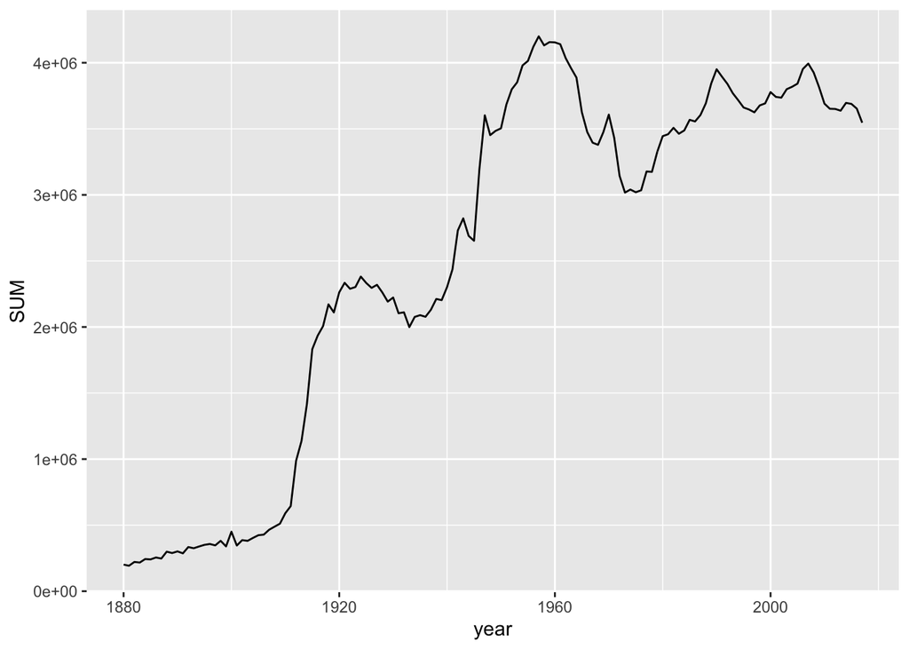

```r
babynames %>%
  group_by(year) %>%
  summarize(SUM = sum(number)) %>%
  ggplot(aes(year, SUM)) +
    geom_line()
```

- Давайте увидим что-то интересное. Посмотрим как “Игра Престолов” влияет на ее поклонников. Посмотрим на динамику имя `Arya` и `Emilia`.

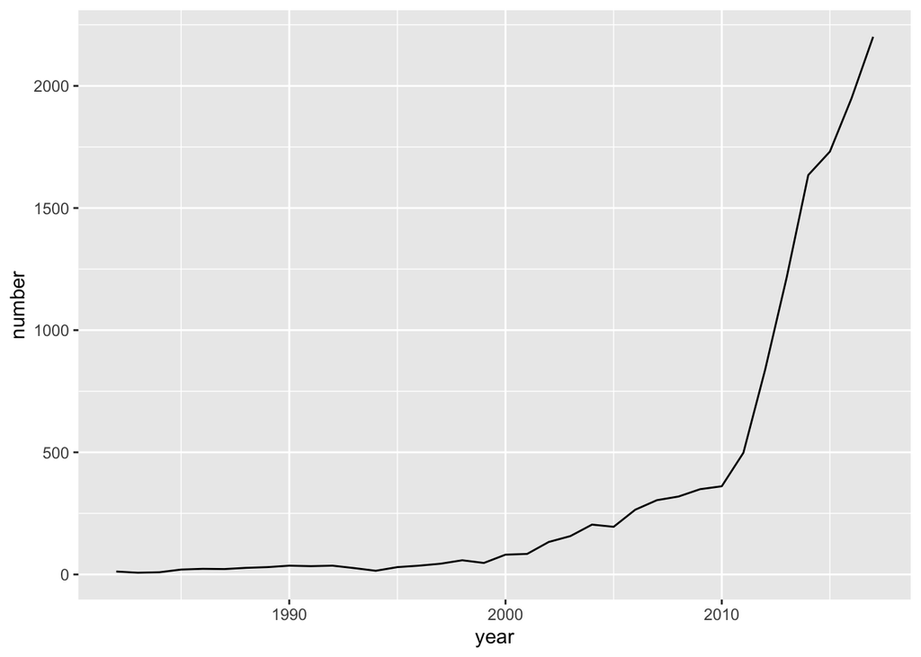

```r
babynames %>%
  filter(name == 'Arya') %>%
  ggplot(aes(x = year, y = number)) +
    geom_line()
```

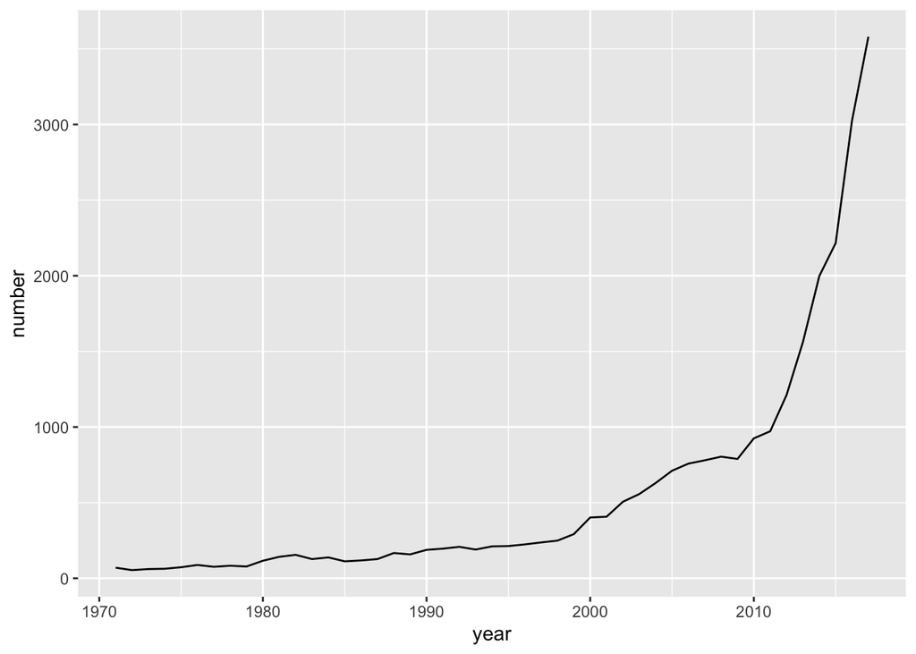

```r
babynames %>%
  filter(name == 'Emilia', year > 1970) %>%
  ggplot(aes(x = year, y = number)) +
    geom_line()
```

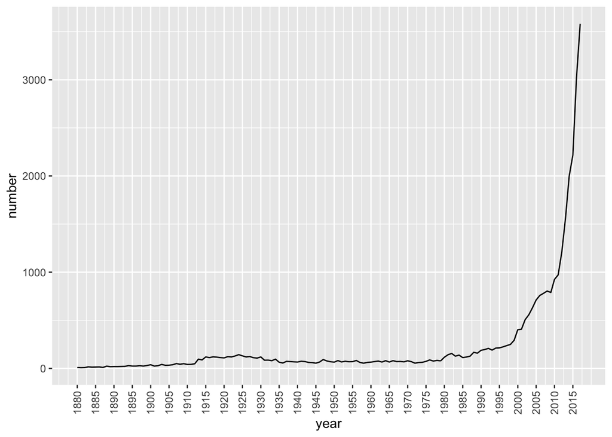

```r
babynames_Emilia <- babynames %>%
                    filter(name == 'Emilia')
MIN <- min(babynames_Emilia$year)
MAX <- max(babynames_Emilia$year)
ggplot(babynames_Emilia, aes(x = year, y = number)) +
  geom_line() +
  theme(axis.text.x = element_text(angle = 90, vjust = 0.5)) +
  scale_x_continuous(breaks = seq(MIN, MAX, 5))
```

- Вывести самое популярное имя за каждый год.

```r
babynames %>%
  group_by(year) %>%
  top_n(1, number)
```

```
## # A tibble: 138 x 3
## # Groups:   year [138]
##     year name  number
##    <dbl> <chr>  <int>
##  1  1880 John    9701
##  2  1881 John    8795
##  3  1882 John    9597
##  4  1883 John    8934
##  5  1884 John    9428
##  6  1885 Mary    9166
##  7  1886 Mary    9921
##  8  1887 Mary    9935
##  9  1888 Mary   11804
## 10  1889 Mary   11689
## # … with 128 more rows
```

- Посмотреть на графики для имен `Steven`, `Thomas` и `Matthew`.

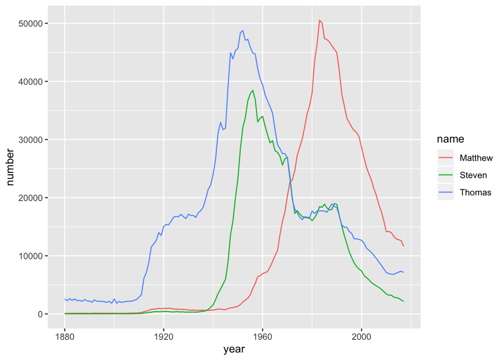

```r
selected_names <- babynames %>%
  filter(name %in% c("Steven", "Thomas", "Matthew"))
ggplot(selected_names, aes(x = year, y = number, color = name)) +
  geom_line()
```

- Вывести для каждого имени год, в котором его доля от всех имен была наибольшей.

```r
babynames %>%
  group_by(year) %>%
  mutate(year_total = sum(number)) %>%
  ungroup() %>%
  mutate(fraction = number / year_total) %>%
  group_by(name) %>%
  top_n(1, fraction)
```

```
## # A tibble: 97,310 x 5
## # Groups:   name [97,310]
##     year name     number year_total  fraction
##    <dbl> <chr>     <int>      <int>     <dbl>
##  1  1880 Abbott        5     201484 0.0000248
##  2  1880 Abe          50     201484 0.000248
##  3  1880 Adelbert     28     201484 0.000139
##  4  1880 Adella       26     201484 0.000129
##  5  1880 Agustus       5     201484 0.0000248
##  6  1880 Albert     1493     201484 0.00741
##  7  1880 Albertus      5     201484 0.0000248
##  8  1880 Alcide        7     201484 0.0000347
##  9  1880 Alonzo      122     201484 0.000606
## 10  1880 Amos        128     201484 0.000635
## # … with 97,300 more rows
```

- Создать колонку, которая будет показывать долю для каждого имени относительно максимального значения для этого имени за весь период.

```r
babynames %>%
  group_by(name) %>%
  mutate(name_max = max(number)) %>%
  ungroup() %>%
  mutate(fraction_max = number/name_max)
```

```
## # A tibble: 1,756,284 x 5
##     year name    number name_max fraction_max
##    <dbl> <chr>    <int>    <int>        <dbl>
##  1  1880 Aaron      102    15411     0.00662
##  2  1880 Ab           5       41     0.122
##  3  1880 Abbie       71      536     0.132
##  4  1880 Abbott       5       59     0.0847
##  5  1880 Abby         6     2048     0.00293
##  6  1880 Abe         50      280     0.179
##  7  1880 Abel         9     3245     0.00277
##  8  1880 Abigail     12    15948     0.000752
##  9  1880 Abner       27      202     0.134
## 10  1880 Abraham     81     2575     0.0315
## # … with 1,756,274 more rows
```